# Tidy word vectors

Chris Beeley

16 December 2018

## Word vectors with tidy data principles

This is based on the blog post [here](https://juliasilge.com/blog/tidy-word-vectors/).

```r
library(stringr)

hacker_news_text <- use_data$Improve %>%
    as_tibble() %>%
    mutate(text = str_replace_all(value, "&quot;|&#x2F;", "'"),    ## hex encoding
           text = str_replace_all(value, "&#x2F;", "/"),           ## more hex
           text = str_replace_all(value, "<a(.*?)>", " "),         ## links
           text = str_replace_all(value, "&gt;|&lt;", " "),        ## html yuck
           text = str_replace_all(value, "<[^>]*>", " "),          ## mmmmm, more html yuck
           postID = row_number()) %>%
  select(-value)
```

## Unigram probabilities

```r
library(tidytext)

unigram_probs <- hacker_news_text %>%
    unnest_tokens(word, text) %>%
    count(word, sort = TRUE) %>%
    mutate(p = n / sum(n))

unigram_probs
```

```
## # A tibble: 17,222 x 3
##    word      n      p
##    <chr> <int>  <dbl>
##  1 to    24846 0.0406
##  2 the   19838 0.0324
##  3 i     15866 0.0259
##  4 more  12505 0.0204
##  5 and   12084 0.0197
##  6 a     10845 0.0177
##  7 of     9432 0.0154
##  8 for    7166 0.0117
##  9 be     7148 0.0117
## 10 not    7034 0.0115
## # … with 17,212 more rows
```

## Skipgram probabilities

```r
library(widyr)

tidy_skipgrams <- hacker_news_text %>%
    unnest_tokens(ngram, text, token = "ngrams", n = 8) %>%
    mutate(ngramID = row_number()) %>%
    unite(skipgramID, postID, ngramID) %>%
    unnest_tokens(word, ngram) %>%
  filter(!is.na(word))

tidy_skipgrams
```

```
## # A tibble: 2,678,648 x 2
##    skipgramID word
##    <chr>      <chr>
##  1 2_2        provide
##  2 2_2        gym
##  3 2_2        staff
##  4 2_2        to
##  5 2_2        get
##  6 2_2        gym
##  7 2_2        up
##  8 2_2        and
##  9 2_3        gym
## 10 2_3        staff
## # … with 2,678,638 more rows
```

```r
skipgram_probs <- tidy_skipgrams %>%
    pairwise_count(word, skipgramID, diag = TRUE, sort = TRUE) %>%
    mutate(p = n / sum(n))
```

## Normalized skipgram probability

We now know how often words occur on their own, and how often words occur together with other words. We can calculate which words occurred together more often than expected based on how often they occurred on their own. When this number is high (greater than 1), the two words are associated with each other, likely to occur together. When this number is low (less than 1), the two words are not associated with each other, unlikely to occur together.

```r
normalized_prob <- skipgram_probs %>%
    filter(n > 20) %>%
    rename(word1 = item1, word2 = item2) %>%
    left_join(unigram_probs %>%
                  select(word1 = word, p1 = p),
              by = "word1") %>%
    left_join(unigram_probs %>%
                  select(word2 = word, p2 = p),
              by = "word2") %>%
    mutate(p_together = p / p1 / p2)
```

What are the words most associated with staff in the data?

```r
normalized_prob %>%
    filter(word1 == "staff") %>%
    arrange(-p_together)
```

```
## # A tibble: 539 x 7
##    word1 word2          n          p      p1        p2 p_together
##    <chr> <chr>      <dbl>      <dbl>   <dbl>     <dbl>      <dbl>
##  1 staff staff      13620 0.000666   0.00650 0.00650        15.8
##  2 staff shortages     91 0.00000445 0.00650 0.0000457      15.0
##  3 staff shortage      67 0.00000328 0.00650 0.0000408      12.4
##  4 staff member       305 0.0000149  0.00650 0.000188       12.2
##  5 staff bank         114 0.00000558 0.00650 0.0000800      10.7
##  6 staff bully         32 0.00000157 0.00650 0.0000229      10.5
##  7 staff facilitate    30 0.00000147 0.00650 0.0000229       9.88
##  8 staff nursing      301 0.0000147  0.00650 0.000230        9.84
##  9 staff shouting      27 0.00000132 0.00650 0.0000212       9.58
## 10 staff members      234 0.0000114  0.00650 0.000202        8.70
## # … with 529 more rows
```

What about access?

```r
normalized_prob %>%
    filter(word1 == "access") %>%
    arrange(-p_together)
```

```
## # A tibble: 114 x 7
##    word1  word2         n          p       p1        p2 p_together
##    <chr>  <chr>     <dbl>      <dbl>    <dbl>     <dbl>      <dbl>
##  1 access access     1932 0.0000945  0.000880 0.000880       122.
##  2 access gain         26 0.00000127 0.000880 0.0000604       23.9
##  3 access internet     21 0.00000103 0.000880 0.0000539       21.7
##  4 access single       43 0.00000210 0.000880 0.000119        20.1
##  5 access direct       32 0.00000157 0.000880 0.000132        13.4
##  6 access therapies    28 0.00000137 0.000880 0.000122        12.7
##  7 access camhs        28 0.00000137 0.000880 0.000122        12.7
##  8 access easier       92 0.00000450 0.000880 0.000415        12.3
##  9 access point        65 0.00000318 0.000880 0.000305        11.8
## 10 access greater      21 0.00000103 0.000880 0.0000996       11.7
## # … with 104 more rows
```

## Cast to a sparse matrix

We want to do matrix factorization, so we should probably make a matrix. We can use cast_sparse() from the tidytext package to transform our tidy data frame to a matrix.

```r
pmi_matrix <- normalized_prob %>%
    mutate(pmi = log10(p_together)) %>%
    cast_sparse(word1, word2, pmi)
```

## Reduce the matrix dimensionality

We want to get information out of this giant matrix in a more useful form, so it’s time for singular value decomposition. Since we have a sparse matrix, we don’t want to use base R’s svd function, which casts the input to a plain old matrix (not sparse) first thing. Instead we will use the fast SVD algorithm for sparse matrices in the irlba package.

```r
library(irlba)
pmi_svd <- irlba(pmi_matrix, 256, maxit = 1e3)
```

The number 256 here means that we are finding 256-dimensional vectors for the words. This is another thing that I am not sure exactly what the best number is, but it will be easy to experiment with. Doing the matrix factorization is another part of this process that is a bit time intensive, but certainly not slow compared to training word2vec on a big corpus. In my experimenting here, it takes less time than counting up the skipgrams.

Once we have the singular value decomposition, we can get out the word vectors! Let’s set some row names, using our input, so we can find out what is what.

```r
word_vectors <- pmi_svd$u
rownames(word_vectors) <- rownames(pmi_matrix)
```

Now we can search our matrix of word vectors to find synonyms. I want to get back to a tidy data structure at this point, so I’ll write a new little function for tidying.

```r
library(broom)

search_synonyms <- function(word_vectors, selected_vector) {

    similarities <- word_vectors %*% selected_vector %>%
        tidy() %>%
        as_tibble() %>%
        rename(token = .rownames,
               similarity = unrowname.x.)

    similarities %>%
        arrange(-similarity)
}

staff <- search_synonyms(word_vectors, word_vectors["staff",])

staff
```

```
## # A tibble: 4,648 x 2
##    token      similarity
##    <chr>           <dbl>
##  1 staff          0.414
##  2 patients       0.0688
##  3 shortages      0.0687
##  4 shortage       0.0652
##  5 shifts         0.0604
##  6 female         0.0589
##  7 shouting       0.0584
##  8 facilitate     0.0579
##  9 male           0.0574
## 10 bank           0.0572
## # … with 4,638 more rows
```

```r
access <- search_synonyms(word_vectors, word_vectors["access",])

access
```

```
## # A tibble: 4,648 x 2
##    token     similarity
##    <chr>          <dbl>
##  1 access        0.239
##  2 point         0.145
##  3 single        0.120
##  4 therapies     0.0958
##  5 gain          0.0942
##  6 direct        0.0672
##  7 internet      0.0632
##  8 via           0.0626
##  9 easier        0.0619
## 10 crisis        0.0581
## # … with 4,638 more rows
```

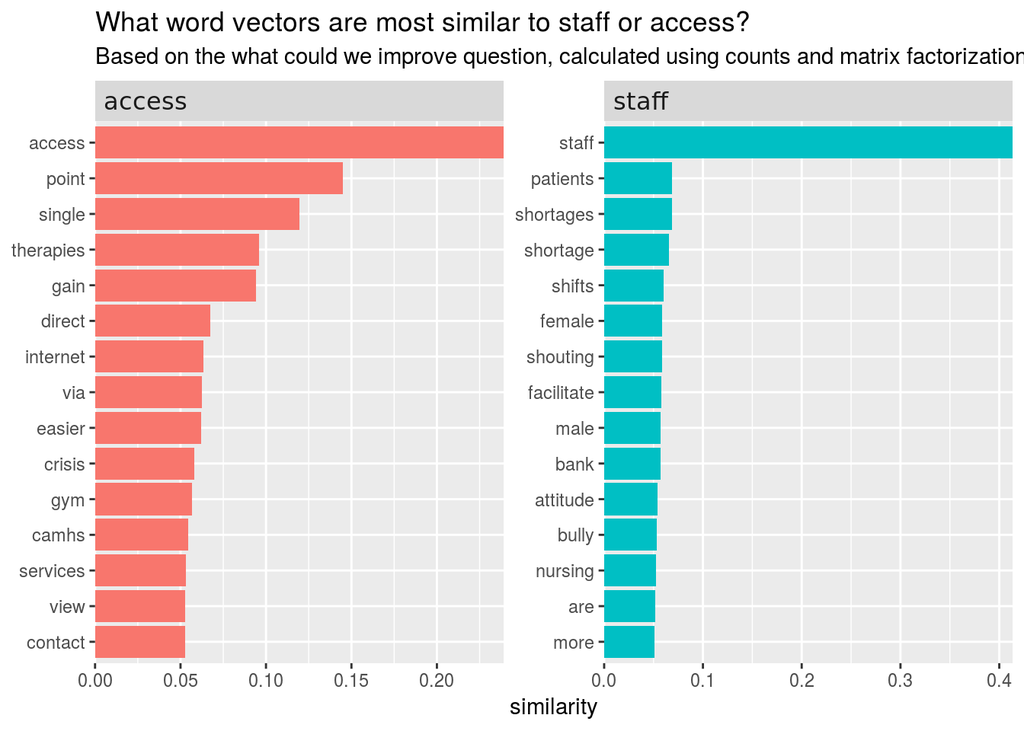

```r
staff %>%
    mutate(selected = "staff") %>%
    bind_rows(access %>%
                  mutate(selected = "access")) %>%
    group_by(selected) %>%
    top_n(15, similarity) %>%
    ungroup %>%
    mutate(token = reorder(token, similarity)) %>%
    ggplot(aes(token, similarity, fill = selected)) +
    geom_col(show.legend = FALSE) +
    facet_wrap(~selected, scales = "free") +
    coord_flip() +
    theme(strip.text=element_text(hjust=0, family="Roboto-Bold", size=12)) +
    scale_y_continuous(expand = c(0,0)) +
    labs(x = NULL, title = "What word vectors are most similar to staff or access?",
         subtitle = "Based on the what could we improve question, calculated using counts and matrix factorization")
```